# Project Description

```python
monitor_df.head()
```

|  | YEAR | MONTH | DAY | HOUR | NH3_CMS1_AVG | H2S_CMS1_AVG | BC_CMS1_AVG | PM25_CMS1_AVG | NH3_CMS2_AVG | H2S_CMS2_AVG | BC_CMS2_AVG | PM25_CMS2_AVG | NH3_CMS3_AVG | H2S_CMS3_AVG | BC_CMS3_AVG | PM25_CMS3_AVG | SO2_UV1_AVG | SO2_UV2_AVG | SO2_UV3_AVG | WS_X_CMS1_AVG | WS_Y_CMS1_AVG | WS_X_CMS2_AVG | WS_Y_CMS2_AVG | WS_X_CMS3_AVG | WS_Y_CMS3_AVG | WS_X_UV1_AVG | WS_Y_UV1_AVG | WS_X_UV2_AVG | WS_Y_UV2_AVG | … |
| --- | --- | --- | --- | --- | --- | --- | --- | --- | --- | --- | --- | --- | --- | --- | --- | --- | --- | --- | --- | --- | --- | --- | --- | --- | --- | --- | --- | --- | --- | --- |
| 0 | 2016 | 1.0 | 1 | 0.0 | 4.868333 | 1.259167 | 4.900750 | 41.0 | 9.064167 | 1.0 | 2.787333 | 18.0 | 4.105000 | 1.261667 | 3.666250 | 26.0 | 5.0 | 5.0 | 5.0 | 1.298252 | -5.742205 | -0.858508 | -1.730956 | 0.165849 | 0.168075 | -1.028100 | -3.129355 | -2.097166 | -1.473645 | … |
| 1 | 2016 | 1.0 | 1 | 1.0 | 4.765000 | 1.087500 | 2.748500 | 27.0 | 8.534167 | 1.0 | 2.206917 | 30.0 | 4.156667 | 1.000000 | 3.675083 | 27.0 | 5.0 | 5.0 | 5.0 | 3.207973 | -6.308830 | -0.219728 | -1.328900 | 0.002908 | 0.083283 | -0.188390 | -3.796677 | -0.506721 | -2.032053 | … |
| 2 | 2016 | 1.0 | 1 | 2.0 | 6.033333 | 1.816667 | 3.496250 | 25.0 | 11.589167 | 1.0 | 2.391417 | 24.0 | 3.680000 | 1.000000 | 2.009667 | 20.0 | 5.0 | 5.0 | 5.0 | 1.398677 | -1.894589 | -0.497117 | -0.663436 | 0.000000 | 0.000000 | -1.153081 | -1.231468 | -0.819376 | -0.347127 | … |
| 3 | 2016 | 1.0 | 1 | 3.0 | 3.443333 | 1.524167 | 3.674083 | 21.0 | 8.965000 | 1.0 | 1.342167 | 25.0 | 3.158333 | 1.000000 | 1.997833 | 14.0 | 5.0 | 5.0 | 5.0 | -2.101173 | -7.432369 | -1.514275 | -1.506292 | 0.000000 | 0.000000 | -2.542529 | -4.296541 | -2.543722 | -1.274732 | … |
| 4 | 2016 | 1.0 | 1 | 4.0 | 4.056667 | 1.000000 | 1.682000 | 26.0 | 7.291667 | 1.0 | 0.810333 | 11.0 | 3.055000 | 1.000000 | 1.812917 | 11.0 | 5.0 | 5.0 | 5.0 | -3.015036 | -7.283977 | -2.058740 | -1.775681 | 0.000000 | 0.000000 | -2.365091 | -2.412874 | -4.252358 | -0.717530 | … |

**Need to parse out the DATE column in the df_aermod dataframe:**

```python
df_aermod['DATE'] = df_aermod['DATE'].astype(str)
df_aermod['YEAR'] = df_aermod['DATE'].str[:2]
df_aermod['MONTH'] = df_aermod['DATE'].str[2:4]
df_aermod['DAY'] = df_aermod['DATE'].str[4:6]
df_aermod['HOUR'] = df_aermod['DATE'].str[6:]
df_aermod['YEAR'] = pd.to_numeric(df_aermod.YEAR,errors='coerce')
df_aermod['YEAR'] = df_aermod['YEAR']+2000
df_aermod['MONTH'] = pd.to_numeric(df_aermod.MONTH,errors='coerce')
df_aermod['DAY'] = pd.to_numeric(df_aermod.DAY,errors='coerce')
df_aermod['HOUR'] = pd.to_numeric(df_aermod.HOUR,errors='coerce')
```

```python
df_aermod.head()
```

|  | DATE | S1_UV1_1 | S1_UV1_10 | S1_UV1_11 | S1_UV1_12 | S1_UV1_13 | S1_UV1_14 | S1_UV1_15 | S1_UV1_16 | S1_UV1_17 | S1_UV1_18 | S1_UV1_19 | S1_UV1_2 | S1_UV1_20 | S1_UV1_21 | S1_UV1_3 | S1_UV1_4 | S1_UV1_5 | S1_UV1_6 | S1_UV1_7 | S1_UV1_8 | S1_UV1_9 | S1_CMS1 | S1_GLM1 | S1_GLM2 | S1_GLM3 | S1_CMS2 | S1_UV2_1 | S1_UV2_10 | … |
| --- | --- | --- | --- | --- | --- | --- | --- | --- | --- | --- | --- | --- | --- | --- | --- | --- | --- | --- | --- | --- | --- | --- | --- | --- | --- | --- | --- | --- | --- | --- |
| 0 | 16010101 | 0.0 | 0.0 | 0.0 | 0.0 | 0.0 | 0.0 | 0.0 | 0.0 | 0.0 | 0.0 | 0.0 | 0.0 | 0.0 | 0.0 | 0.0 | 0.0 | 0.0 | 0.0 | 0.0 | 0.0 | 0.0 | 0.0 | 0.0 | 0.0 | 0.0 | 0.0 | 0.0 | 0.0 | … |
| 1 | 16010102 | 0.0 | 0.0 | 0.0 | 0.0 | 0.0 | 0.0 | 0.0 | 0.0 | 0.0 | 0.0 | 0.0 | 0.0 | 0.0 | 0.0 | 0.0 | 0.0 | 0.0 | 0.0 | 0.0 | 0.0 | 0.0 | 0.0 | 0.0 | 0.0 | 0.0 | 0.0 | 0.0 | 0.0 | … |
| 2 | 16010103 | 0.0 | 0.0 | 0.0 | 0.0 | 0.0 | 0.0 | 0.0 | 0.0 | 0.0 | 0.0 | 0.0 | 0.0 | 0.0 | 0.0 | 0.0 | 0.0 | 0.0 | 0.0 | 0.0 | 0.0 | 0.0 | 0.0 | 0.0 | 0.0 | 0.0 | 0.0 | 0.0 | 0.0 | … |
| 3 | 16010104 | 0.0 | 0.0 | 0.0 | 0.0 | 0.0 | 0.0 | 0.0 | 0.0 | 0.0 | 0.0 | 0.0 | 0.0 | 0.0 | 0.0 | 0.0 | 0.0 | 0.0 | 0.0 | 0.0 | 0.0 | 0.0 | 0.0 | 0.0 | 0.0 | 0.0 | 0.0 | 0.0 | 0.0 | … |
| 4 | 16010105 | 0.0 | 0.0 | 0.0 | 0.0 | 0.0 | 0.0 | 0.0 | 0.0 | 0.0 | 0.0 | 0.0 | 0.0 | 0.0 | 0.0 | 0.0 | 0.0 | 0.0 | 0.0 | 0.0 | 0.0 | 0.0 | 0.0 | 0.0 | 0.0 | 0.0 | 0.0 | 0.0 | 0.0 | … |

**Delete the original DATE column, and subtract 1 from HOUR to match it up with other dataframes (hour goes from 0-23, rather than 1-24):**

```python
df_aermod = df_aermod.drop(columns=['DATE'])
df_aermod['HOUR'] = df_aermod['HOUR']-1
```

**Merge on monitor_df, create a new full dataframe df_ml (dataframe for machine learning):**

```python
df_ml = df_aermod.copy()
df_ml = df_ml.merge(monitor_df, on=['YEAR','MONTH','DAY','HOUR'])
df_ml.shape
```

```
(17544, 320)
```

```python
df_ml.head()
```

|  | S1_UV1_1 | S1_UV1_10 | S1_UV1_11 | S1_UV1_12 | S1_UV1_13 | S1_UV1_14 | S1_UV1_15 | S1_UV1_16 | S1_UV1_17 | S1_UV1_18 | S1_UV1_19 | S1_UV1_2 | S1_UV1_20 | S1_UV1_21 | S1_UV1_3 | S1_UV1_4 | S1_UV1_5 | S1_UV1_6 | S1_UV1_7 | S1_UV1_8 | S1_UV1_9 | S1_CMS1 | S1_GLM1 | S1_GLM2 | S1_GLM3 | S1_CMS2 | S1_UV2_1 | S1_UV2_10 | S1_UV2_2 | … |
| --- | --- | --- | --- | --- | --- | --- | --- | --- | --- | --- | --- | --- | --- | --- | --- | --- | --- | --- | --- | --- | --- | --- | --- | --- | --- | --- | --- | --- | --- | --- |
| 0 | 0.0 | 0.0 | 0.0 | 0.0 | 0.0 | 0.0 | 0.0 | 0.0 | 0.0 | 0.0 | 0.0 | 0.0 | 0.0 | 0.0 | 0.0 | 0.0 | 0.0 | 0.0 | 0.0 | 0.0 | 0.0 | 0.0 | 0.0 | 0.0 | 0.0 | 0.0 | 0.0 | 0.0 | 0.0 | … |
| 1 | 0.0 | 0.0 | 0.0 | 0.0 | 0.0 | 0.0 | 0.0 | 0.0 | 0.0 | 0.0 | 0.0 | 0.0 | 0.0 | 0.0 | 0.0 | 0.0 | 0.0 | 0.0 | 0.0 | 0.0 | 0.0 | 0.0 | 0.0 | 0.0 | 0.0 | 0.0 | 0.0 | 0.0 | 0.0 | … |
| 2 | 0.0 | 0.0 | 0.0 | 0.0 | 0.0 | 0.0 | 0.0 | 0.0 | 0.0 | 0.0 | 0.0 | 0.0 | 0.0 | 0.0 | 0.0 | 0.0 | 0.0 | 0.0 | 0.0 | 0.0 | 0.0 | 0.0 | 0.0 | 0.0 | 0.0 | 0.0 | 0.0 | 0.0 | 0.0 | … |
| 3 | 0.0 | 0.0 | 0.0 | 0.0 | 0.0 | 0.0 | 0.0 | 0.0 | 0.0 | 0.0 | 0.0 | 0.0 | 0.0 | 0.0 | 0.0 | 0.0 | 0.0 | 0.0 | 0.0 | 0.0 | 0.0 | 0.0 | 0.0 | 0.0 | 0.0 | 0.0 | 0.0 | 0.0 | 0.0 | … |
| 4 | 0.0 | 0.0 | 0.0 | 0.0 | 0.0 | 0.0 | 0.0 | 0.0 | 0.0 | 0.0 | 0.0 | 0.0 | 0.0 | 0.0 | 0.0 | 0.0 | 0.0 | 0.0 | 0.0 | 0.0 | 0.0 | 0.0 | 0.0 | 0.0 | 0.0 | 0.0 | 0.0 | 0.0 | 0.0 | … |

**Merge on met_all:**

```python
df_ml = df_ml.merge(met_all, on=['YEAR','MONTH','DAY','HOUR'])
df_ml.shape
```

```
(17544, 324)
```

```python
df_ml.head()
```

|  | S1_UV1_1 | S1_UV1_10 | S1_UV1_11 | S1_UV1_12 | S1_UV1_13 | S1_UV1_14 | S1_UV1_15 | S1_UV1_16 | S1_UV1_17 | S1_UV1_18 | S1_UV1_19 | S1_UV1_2 | S1_UV1_20 | S1_UV1_21 | S1_UV1_3 | S1_UV1_4 | S1_UV1_5 | S1_UV1_6 | S1_UV1_7 | S1_UV1_8 | S1_UV1_9 | S1_CMS1 | S1_GLM1 | S1_GLM2 | S1_GLM3 | S1_CMS2 | S1_UV2_1 | S1_UV2_10 | S1_UV2_2 | … |
| --- | --- | --- | --- | --- | --- | --- | --- | --- | --- | --- | --- | --- | --- | --- | --- | --- | --- | --- | --- | --- | --- | --- | --- | --- | --- | --- | --- | --- | --- | --- |
| 0 | 0.0 | 0.0 | 0.0 | 0.0 | 0.0 | 0.0 | 0.0 | 0.0 | 0.0 | 0.0 | 0.0 | 0.0 | 0.0 | 0.0 | 0.0 | 0.0 | 0.0 | 0.0 | 0.0 | 0.0 | 0.0 | 0.0 | 0.0 | 0.0 | 0.0 | 0.0 | 0.0 | 0.0 | 0.0 | … |
| 1 | 0.0 | 0.0 | 0.0 | 0.0 | 0.0 | 0.0 | 0.0 | 0.0 | 0.0 | 0.0 | 0.0 | 0.0 | 0.0 | 0.0 | 0.0 | 0.0 | 0.0 | 0.0 | 0.0 | 0.0 | 0.0 | 0.0 | 0.0 | 0.0 | 0.0 | 0.0 | 0.0 | 0.0 | 0.0 | … |
| 2 | 0.0 | 0.0 | 0.0 | 0.0 | 0.0 | 0.0 | 0.0 | 0.0 | 0.0 | 0.0 | 0.0 | 0.0 | 0.0 | 0.0 | 0.0 | 0.0 | 0.0 | 0.0 | 0.0 | 0.0 | 0.0 | 0.0 | 0.0 | 0.0 | 0.0 | 0.0 | 0.0 | 0.0 | 0.0 | … |
| 3 | 0.0 | 0.0 | 0.0 | 0.0 | 0.0 | 0.0 | 0.0 | 0.0 | 0.0 | 0.0 | 0.0 | 0.0 | 0.0 | 0.0 | 0.0 | 0.0 | 0.0 | 0.0 | 0.0 | 0.0 | 0.0 | 0.0 | 0.0 | 0.0 | 0.0 | 0.0 | 0.0 | 0.0 | 0.0 | … |
| 4 | 0.0 | 0.0 | 0.0 | 0.0 | 0.0 | 0.0 | 0.0 | 0.0 | 0.0 | 0.0 | 0.0 | 0.0 | 0.0 | 0.0 | 0.0 | 0.0 | 0.0 | 0.0 | 0.0 | 0.0 | 0.0 | 0.0 | 0.0 | 0.0 | 0.0 | 0.0 | 0.0 | 0.0 | 0.0 | … |

**Almost there - introduce a couple of new features for time, including weekend (0 = not weekend, 1 = weekend), and the sine and cosine of Julian day to help capture any seasonal variability. This is a common feature in many air quality studies. These functions connect the similarity between December and January across years.**

```python
df_ml['DATETIME'] = pd.to_datetime(dict(year=df_ml.YEAR,month=df_ml.MONTH,day=df_ml.DAY))
df_ml['JDAY'] = df_ml['DATETIME'].dt.strftime('%j')
df_ml['JDAY'] = pd.to_numeric(df_ml.JDAY,errors='coerce')
df_ml['DAYOFWEEK'] = df_ml['DATETIME'].dt.dayofweek+1
df_ml['WEEKEND'] = df_ml['DAYOFWEEK'].apply(lambda x:1 if x>5 else 0)
df_ml['SIN_JDAY'] = np.sin(2*math.pi*df_ml['JDAY']/365)
df_ml['COS_JDAY'] = np.cos(2*math.pi*df_ml['JDAY']/365)
```

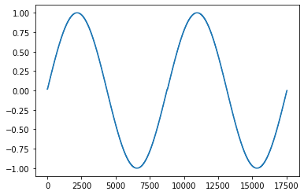

```python
plt.plot(df_ml['SIN_JDAY'])
```

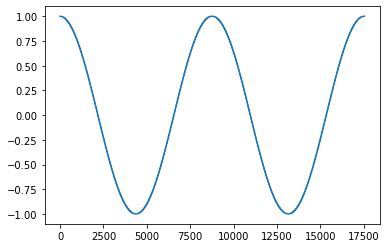

```python
plt.plot(df_ml['COS_JDAY'])
```

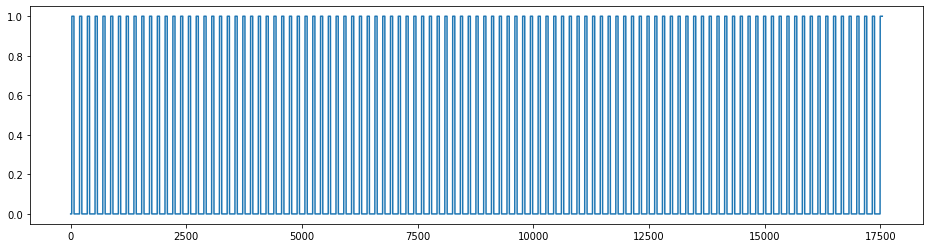

```python
plt.figure(figsize=(16,4))
plt.plot(df_ml['WEEKEND'])
```

**All good, now save the full dataframe as a pickle for easy access later:**

```python
df_ml.to_pickle("data/df_ml.pkl")
```

# Transformations

# Model Training

**The workflow here will be as follows:**

- **For each of 7 monitors (4 ground level monitors, 3 UV fenceline monitors), filter the dataset for the top 10% of hits (i.e., for a 17544 hour dataset spanning 2016-2017, select the top 1754 hours and use that for model fitting).**
- **Use a 70/30 train/test split on the data.**
- **For each monitor, use 4 different regression models to predict aggregated emissions from nearby sources: Ridge, Random Forests, XGBoost, Neural Networks. These are the most commonly tested models in air quality machine learning studies - typically Ridge performs the worst and serves as a "baseline" for how simple regression models do, and RF/XGB/NN do a lot better.**
- **For regression/RF/XGB, store the regression coefficients/feature importances to look at after training for physical intuition.**
- **Store the R^2 score for each model fitting to the test set as a metric of performance.**

**Last note: since SO2 is the best proxy for our "mystery pollutant" since they are usually emitted by the same processes (combustion of impurities in coal or petroleum), we will use SO2 concentrations to filter our dataset for the top 10%.**

**Define function for R^2 to be used with Keras NN model:**

```python
def r2(X, y, model):
    y = np.array(y).reshape((y.shape[0],1))
    RSS = np.sum(np.square(y-np.array(model.predict(X))))
    TSS = np.sum(np.square(y-np.mean(y)))
    return (1-RSS/TSS)
```

**All-purpose function for model fitting, comments in code block below:**

```python
def create_model(X, y, model_type, pca_apply = False):
    '''
    X = dataframe of all features
    y = dataframe of target variable
    model_type = name of model type, defined in code below
    pca_apply = option to apply PCA for ridge regression
    '''
    # Use a 70/30 train/test split
    X_train, X_test, y_train, y_test = train_test_split(X,y,test_size=0.3,random_state=0)

    # Empty dataframes/dictionaries to store results
    scores = pd.DataFrame(columns=['Train_R2','Test_R2'])

    # Create object for model type based on input, which should be one of four options:
    # Ridge: Ridge linear regression, using K=10 cross validation to select the best alpha
    # RF: Random Forests (assuming default n_estimators of 100)
    # XGB: Extreme Gradient Boosting (assuming default n_estimators of 100)
    # NN: Neural Networks using Keras (assuming a 500 unit layer --> 20% dropout --> 100 unit layer --> 20% dropout)
    if model_type == "Ridge":
        alphas = [0.01, 0.1, 1, 10, 100]
        model = RidgeCV(alphas=alphas, normalize=True, cv=10)
    elif model_type == "RF":
        model = RandomForestRegressor(n_estimators=100)
    elif model_type == "XGB":
        model = XGBRegressor(n_estimators=100, objective='reg:squarederror')
    elif model_type == "NN":
        model = Sequential()
        model.add(Dense(500, input_dim=X.shape[1], activation='relu'))
        model.add(Dropout(0.2))
        model.add(Dense(100, activation='relu'))
        model.add(Dropout(0.2))
        model.add(Dense(1))
        model.compile(optimizer='adam', loss='mse')

    # Model fitting for all model types
    if model_type == "Ridge":
        if pca_apply:
            pca = PCA()
            X_train_pca = pca.fit_transform(X_train)
            X_test_pca = pca.transform(X_test)
            pca = PCA(n_components=np.argwhere(np.cumsum(pca.explained_variance_ratio_) > 0.999)[0][0])
            X_train_pca = pca.fit_transform(X_train)
            X_test_pca = pca.transform(X_test)
            model.fit(X_train_pca, y_train)
            train_score = model.score(X_train_pca, y_train)
            test_score = model.score(X_test_pca, y_test)
            scores = scores.append({'Train_R2':train_score, 'Test_R2':test_score}, ignore_index=True)
        else:
            model.fit(X_train, y_train)
            train_score = model.score(X_train, y_train)
            test_score = model.score(X_test, y_test)
            scores = scores.append({'Train_R2':train_score, 'Test_R2':test_score}, ignore_index=True)
    elif model_type == "NN":
        model.fit(X_train, y_train, epochs=500, batch_size=X_train.shape[0], verbose=False, validation_data=(X_test,y_test))
        train_score = r2(X_train, y_train, model)
        test_score = r2(X_test, y_test, model)
        scores = scores.append({'Train_R2':train_score, 'Test_R2':test_score}, ignore_index=True)
    else:
        model.fit(X_train, y_train)
        train_score = model.score(X_train, y_train)
        test_score = model.score(X_test, y_test)
        scores = scores.append({'Train_R2':train_score, 'Test_R2':test_score}, ignore_index=True)

    # For Ridge, store the fitted coefficients
    # For RF and XGB, store the feature importances
    if model_type == "Ridge":
        if not pca_apply:
            coefs = pd.DataFrame()
            coefs['feature'] = X_train.columns
            coefs['coef'] = model.coef_
            coefs = coefs.sort_values('coef', ascending=False)
            imp = coefs
            y_pred = model.predict(X_test)
        else:
            y_pred = model.predict(X_test_pca)
    elif model_type == "NN":
        y_pred = model.predict(X_test)
        imp = pd.DataFrame()
    else:
        imp = pd.DataFrame()
        imp['feature'] = X_train.columns
        imp['importance'] = model.feature_importances_
        imp = imp.sort_values('importance', ascending=False)
        y_pred = model.predict(X_test)
    return scores, imp, y_pred, y_test
```

**Function creates a full pipeline for model training and testing:**

- **Filters data for the top 10% of hits (90th percentile and above)**
- **Performs a Box-Cox transformation on the dataframe of predictors**
- **Merges on emissions dataframe to get rows corresponding to the top 10% of hits, then separates out the dataframes back into separate sets**
- **Scales the dataframe of predictors (X)**
- **Creates separate source groupings for emissions totals based on the input to the function**
- **Calls the previously created "create_model" function for model fitting and scoring**
- **Returns a dataframe of all test_scores for all combinations**

```python
def model_pipeline(df, emis_df, monitors, model_types):
    '''
    df = dataframe of all features
    emis_df = dataframe of emissions
    monitors = selected monitors, must match column names in df
    model_type = model type to be used in create_model function
    '''
    test_scores = pd.DataFrame(index=monitors, columns=[col+"_R2" for col in model_types])
    coefs_dict = {}
    y_preds_dict = {}
    y_tests_dict = {}
    for monitor in monitors:
        so2_threshold = np.percentile(df[monitor],90)
        df_filter = df.copy()
        df_filter = df_filter.loc[df_filter[monitor] > so2_threshold]
        for feature in df_filter.columns:
            if feature not in ['DATETIME','YEAR','MONTH','DAY','HOUR','JDAY','DAYOFWEEK','WEEKEND','SIN_JDAY','COS_JDAY','year','month','day','hour']:
                if df_filter[feature].min() <= 0:
                    df_filter[feature] = df_filter[feature]-df_filter[feature].min()+0.01
                df_filter[feature],boxcox_lambda = boxcox(df_filter[feature])
        df_filter = df_filter.merge(emis_df, left_on=['YEAR','MONTH','DAY','HOUR'], right_on=['year','month','day','hour'], how='left')
        df_filter = df_filter.drop(columns=['DATETIME','HOUR','JDAY','YEAR','MONTH','DAY','DAYOFWEEK','year','month','day','hour'])
        emis = df_filter['emisrate']
        df_filter = df_filter.drop(columns=['emisrate'])
        scaler = StandardScaler()
        X = pd.DataFrame(scaler.fit_transform(df_filter), index=df_filter.index, columns=df_filter.columns)
        for model_type in model_types:
            scores, coefs, y_pred, y_test = create_model(X, emis, model_type)
            test_scores.loc[monitor,model_type+"_R2"] = scores['Test_R2'].values[0]
            if model_type != "NN":
                coefs_dict[model_type+"_"+monitor] = coefs
            y_preds_dict[model_type+"_"+monitor] = y_pred
            y_tests_dict[model_type+"_"+monitor] = y_test
    return test_scores, coefs_dict, y_preds_dict, y_tests_dict
```

```python
df = df_ml.copy()
monitors = ['SO2_UV1_AVG','SO2_UV2_AVG','SO2_UV3_AVG','SO2_GLM1','SO2_GLM2','SO2_GLM3','SO2_GLM4']
model_types = ['Ridge','RF','XGB','NN']
```

```python
scores_all, coefs_all, y_preds, y_tests = model_pipeline(df, emis, monitors, model_types)
```

[output not shown]

[output not shown]

```python
scores_all
```

|  | Ridge_R2 | RF_R2 | XGB_R2 | NN_R2 |
| --- | --- | --- | --- | --- |
| SO2_UV1_AVG | 0.43374 | 0.649964 | 0.668676 | 0.596016 |
| SO2_UV2_AVG | 0.706358 | 0.82556 | 0.828598 | 0.820303 |
| SO2_UV3_AVG | 0.6245 | 0.752672 | 0.786814 | 0.782851 |
| SO2_GLM1 | 0.588201 | 0.809035 | 0.777889 | 0.740963 |
| SO2_GLM2 | 0.503858 | 0.744768 | 0.73577 | 0.647275 |
| SO2_GLM3 | 0.83092 | 0.870904 | 0.875905 | 0.854002 |
| SO2_GLM4 | 0.518571 | 0.760323 | 0.724531 | 0.729463 |

**The prediction for aggregated emissions using the top 10% of concentrations measured at the GLM3 station produces the best results. This isn't too surprising, since GLM3 is the closest monitor to the largest emissions source of mystery pollutant "X" (what we're trying to predict). The SO2 UV1 fenceline, GLM2 monitor, and GLM4 monitor are the monitors that are furthest out from the major pollution sources.**

**Let's look at the emissions predicting using the GLM3 subset in more detail:**

```python
coefs_all['Ridge_SO2_GLM3']
```

|  | feature | coef |
| --- | --- | --- |
| 98 | S4_GLM3 | 0.168373 |
| 135 | S5_GLM3 | 0.122395 |
| 111 | S5_UV1_1 | 0.116514 |
| 73 | S2_CMS3 | 0.115878 |
| 74 | S4_UV1_1 | 0.115584 |
| 227 | H2S_CMS2_AVG | 0.101774 |
| 169 | S6_CMS1 | 0.098182 |
| 261 | BC_CMS3_MAX | 0.097293 |
| 143 | S5_UV2_6 | 0.084060 |
| 62 | S2_CMS2 | 0.083775 |
| 209 | S3_GLM3 | 0.080856 |
| 77 | S4_UV1_12 | 0.080380 |
| 144 | S5_UV2_7 | 0.076950 |
| 78 | S4_UV1_13 | 0.073606 |
| 277 | WS_Y_UV3_MAX | 0.070065 |
| 114 | S5_UV1_12 | 0.069008 |
| 58 | S2_CMS1 | 0.065985 |
| 223 | H2S_CMS1_AVG | 0.063914 |
| 115 | S5_UV1_13 | 0.062467 |
| 113 | S5_UV1_11 | 0.060964 |
| 147 | S5_CMS3 | 0.058440 |
| 240 | WS_Y_CMS2_AVG | 0.055814 |
| 264 | SO2_UV2_MAX | 0.053125 |
| 260 | H2S_CMS3_MAX | 0.052964 |
| 289 | H2S_CMS3_VAR | 0.052850 |
| 112 | S5_UV1_10 | 0.049152 |
| 79 | S4_UV1_14 | 0.048379 |
| 316 | SOLAR_GHI | 0.043413 |
| 116 | S5_UV1_14 | 0.043101 |
| 137 | S5_UV2_1 | 0.042302 |

[output cut: 292 more lines]

```python
coefs_all['RF_SO2_GLM3']
```

|  | feature | importance |
| --- | --- | --- |
| 24 | S1_GLM3 | 0.244977 |
| 98 | S4_GLM3 | 0.056237 |
| 27 | S1_UV2_10 | 0.050409 |
| 0 | S1_UV1_1 | 0.048037 |
| 21 | S1_CMS1 | 0.039698 |
| 318 | STP | 0.025890 |
| 209 | S3_GLM3 | 0.020959 |
| 3 | S1_UV1_12 | 0.015012 |
| 266 | WS_X_CMS1_MAX | 0.014843 |
| 25 | S1_CMS2 | 0.012850 |
| 227 | H2S_CMS2_AVG | 0.012038 |
| 130 | S5_UV1_8 | 0.011848 |
| 22 | S1_GLM1 | 0.011403 |
| 321 | COS_JDAY | 0.011370 |
| 74 | S4_UV1_1 | 0.010912 |
| 135 | S5_GLM3 | 0.010781 |
| 4 | S1_UV1_13 | 0.010157 |
| 132 | S5_CMS1 | 0.007455 |
| 320 | SIN_JDAY | 0.006719 |
| 136 | S5_CMS2 | 0.006714 |
| 5 | S1_UV1_14 | 0.006472 |
| 226 | NH3_CMS2_AVG | 0.006360 |
| 251 | NH3_CMS1_MAX | 0.005955 |
| 267 | WS_Y_CMS1_MAX | 0.005789 |
| 6 | S1_UV1_15 | 0.005015 |
| 309 | SO2_GLM1 | 0.004903 |
| 256 | H2S_CMS2_MAX | 0.004839 |
| 238 | WS_Y_CMS1_AVG | 0.004830 |
| 133 | S5_GLM1 | 0.004633 |
| 75 | S4_UV1_10 | 0.004508 |

[output cut: 292 more lines]

```python
coefs_all['XGB_SO2_GLM3']
```

|  | feature | importance |
| --- | --- | --- |
| 84 | S4_UV1_19 | 0.089880 |
| 13 | S1_UV1_21 | 0.061503 |
| 88 | S4_UV1_3 | 0.041771 |
| 82 | S4_UV1_17 | 0.040508 |
| 5 | S1_UV1_14 | 0.036261 |
| 102 | S4_UV2_2 | 0.035773 |
| 80 | S4_UV1_15 | 0.030742 |
| 77 | S4_UV1_12 | 0.029595 |
| 130 | S5_UV1_8 | 0.026930 |
| 4 | S1_UV1_13 | 0.026085 |
| 104 | S4_UV2_4 | 0.023920 |
| 222 | NH3_CMS1_AVG | 0.022308 |
| 208 | S3_GLM2 | 0.020266 |
| 27 | S1_UV2_10 | 0.019424 |
| 3 | S1_UV1_12 | 0.018587 |
| 248 | WS_Y_UV3_AVG | 0.016483 |
| 85 | S4_UV1_2 | 0.016189 |
| 107 | S4_UV2_7 | 0.015610 |
| 227 | H2S_CMS2_AVG | 0.014440 |
| 184 | S6_CMS3 | 0.014060 |
| 98 | S4_GLM3 | 0.013866 |
| 25 | S1_CMS2 | 0.013823 |
| 24 | S1_GLM3 | 0.013819 |
| 136 | S5_CMS2 | 0.013805 |
| 21 | S1_CMS1 | 0.013451 |
| 0 | S1_UV1_1 | 0.013239 |
| 99 | S4_CMS2 | 0.012311 |
| 135 | S5_GLM3 | 0.011542 |
| 209 | S3_GLM3 | 0.011490 |
| 169 | S6_CMS1 | 0.011391 |

[output cut: 292 more lines]

**Physical insights that we can draw from the ridge coefficients and feature importances:**

- **Across all three models, the most important features tend to be dispersion factors originating from S1, S4, and S5, and ending at GLM3 or one of the UV1 fenceline receptors. Recall that a dispersion factor measures the source/strength coupling at any given hour, and is affected by meteorology and terrain - a high dispersion factor means favorable transport from one source to a given receptor. In layman's terms, we should expect a higher emissions prediction when certain dispersion factors are high (i.e., when winds blow from the highest emitting sources towards the monitors), and we should also expect to see an inverse relationship with other dispersion factors (i.e., representative of times when winds blow from the highest emitting sources away from the monitors of interest, towards other monitors in different directions).**
- **Example: the ridge regression coefficients show the strongest positive predictor is S4_GLM3, while the strongest negative predictor is S1_GLM3. When S4_GLM3 is high, winds blow from source S4 towards monitor GLM3. S4 is the largest source of mystery pollutant X in the region, so this feature should naturally correlate well with a high emissions prediction. Meanwhile, S1 is a relatively small source of pollutant X, and is on the opposite side of the monitor compared to S4. So when winds blow from S1 to GLM3, the monitors are only seeing a small reading of pollutant X, while larger emissions sources are being blown away from the monitors in a different direction.**

**Let's look at some scatterplots of predicted vs. true values for the test set:**

**Ridge:**

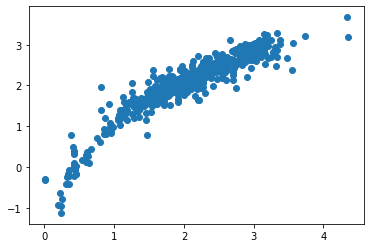

```python
plt.scatter(y_tests['Ridge_SO2_GLM3'], y_preds['Ridge_SO2_GLM3'])
```

**Random Forests:**

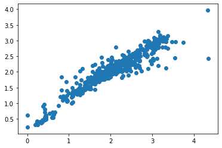

```python
plt.scatter(y_tests['RF_SO2_GLM3'], y_preds['RF_SO2_GLM3'])
```

**XGBoost:**

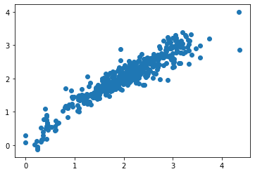

```python
plt.scatter(y_tests['XGB_SO2_GLM3'], y_preds['XGB_SO2_GLM3'])
```

**Neural Networks:**

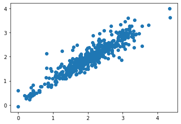

```python
plt.scatter(y_tests['NN_SO2_GLM3'], y_preds['NN_SO2_GLM3'])
```

**Observations:**

- **Ridge produces the poorest results, and the trend looks more like a square root than a linear trend. The model also predicts negative values, which is not possible. As mentioned at the beginning the purpose of the ridge model is to observe feature coefficients, not for predictive value.**
- **Both tree-based models predict well at lower emissions values, but start to diverge a bit at higher values. Neural networks are somewhat the opposite.**
- **Model stacking could produce a better result, and would potentially be a topic of future work. It has not seen much use in the air quality community yet.**

# Conclusions and Future Work

**In this project, I was able to build a reasonably good predictor of emissions events corresponding to the top 10% of concentration hits at a given air quality monitor using tree-based models (Random Forests and XGBoost) and neural networks. These models could serve as a much more time-efficient method compared to traditional inverse air quality models. We saw that even without explicit information on concentrations of "mystery pollutant X", we were able to accurately predict aggregated emissions from a variety of different sources in the region.**

**With more time, I would explore model stacking and model tuning to optimize the models for better prediction. I would also explore other datasets, such as including traffic, rail, or shipping data, which are non-negligible sources of pollutant X.**

**Due to the non-zero degree of uncertainty with using machine learning for air quality prediciton, it is unlikely that these types of models would gain approval for use by EPA or local air quality agencies. However, many existing air quality data projects use machine learning to predict air quality trends in order to help inform the public of current and upcoming air quality.**